# Code used to generate paper results : PMD analysis

Julie Devis

2023-08-28

```r
library(readr)
library(CTexploreR)
library(biomaRt)
library(tidyverse)
library(SummarizedExperiment)
library(BiocParallel)
library(patchwork)
library(Biostrings)
```

This should be completed using another model of senescene/immortalization by confirming the difference between CTs and PMDs, and CTs and nonCT in PMDs.

# 1 Package application : What are the mechanisms involved in CT demethylation in cancer

## 1.1 Determination of PMDs in male fibroblasts celles

WGBS data from GM23248 cells (male so X chromosome is reliable) downloaded from ENCODE. Data was processed using a WGBS pipeline [MethPipe] (http://smithlabresearch.org/software/methpipe/) including [TrimGalore](https://www.bioinformatics.babraham.ac.uk/projects/trim_galore/) to remove low quality reads and trim the adapter from the sequences.

The pipeline has been verified by comparing PMDs already defined by Lister et al. on IMR90 and PMDs obtained with MethPipe.

```bash
wget https://www.encodeproject.org/files/ENCFF142GZA/@@download/ENCFF142GZA.fastq.gz
wget https://www.encodeproject.org/files/ENCFF845RUF/@@download/ENCFF845RUF.fastq.gz
wget https://www.encodeproject.org/files/ENCFF968GRR/@@download/ENCFF968GRR.fastq.gz
wget https://www.encodeproject.org/files/ENCFF975YNS/@@download/ENCFF975YNS.fastq.gz
```

```bash
#!/bin/bash
mkdir /data/cbio/2021-mth-julie-devis/WGBS-processing/processed_data/rep1_ENCLB777FMV;
cd /data/cbio/2021-mth-julie-devis/WGBS-processing/processed_data/rep1_ENCLB777FMV
/opt/TrimGalore/trim_galore --fastqc --paired /data/cbio/2021-mth-julie-devis/WGBS-processing/GM23248_data/ENCFF142GZA.fastq /data/cbio/2021-mth-julie-devis/WGBS-processing/GM23248_data/ENCFF845RUF.fastq

mkdir /data/cbio/2021-mth-julie-devis/WGBS-processing/processed_data/rep2_ENCLB436YZI;
cd /data/cbio/2021-mth-julie-devis/WGBS-processing/processed_data/rep2_ENCLB436YZI
/opt/TrimGalore/trim_galore --fastqc --paired /data/cbio/2021-mth-julie-devis/WGBS-processing/GM23248_data/ENCFF975YNS.fastq /data/cbio/2021-mth-julie-devis/WGBS-processing/GM23248_data/ENCFF968GRR.fastq

#!/bin/bash

cd /data/cbio/2021-mth-julie-devis/WGBS-processing/processed_data/ENCODE_GM23248/rep1_ENCLB777FMV;

#Alignement
/home/users/jdevis/walt/bin/walt \
-i /data/cbio/2021-mth-julie-devis/WGBS-processing/genomes/hg38_by_Chr.dbindex \
-1 ENCFF142GZA_val_1.fq \
-2 ENCFF845RUF_val_2.fq \
-o rep1_ENCLB777FMV_mapping.mr;

#Duplicate-remover
LC_ALL=C sort -k 1,1 -k 2,2n -k 3,3n -k 6,6 -o rep1_ENCLB777FMV.mr.sorted_start rep1_ENCLB777FMV_mapping.mr;
/opt/methpipe/build/duplicate-remover -S rep1_ENCLB777FMV_dremove_stat.txt -o rep1_ENCLB777FMV.mr.dremove rep1_ENCLB777FMV.mr.sorted_start;

#bsrate
/opt/methpipe/build/bsrate -c /data/cbio/GENOMES/GRCh38_by_Chr/hgdownload.cse.ucsc.edu/chromosomes \
-o rep1_ENCLB777FMV.bsrate rep1_ENCLB777FMV.mr.dremove;

#Methylation levels
/opt/methpipe/build/methcounts -n \
-c /data/cbio/GENOMES/GRCh38_by_Chr/hgdownload.cse.ucsc.edu/chromosomes \
-o rep1_ENCLB777FMV.meth rep1_ENCLB777FMV.mr.dremove;

#Merge CpG
/opt/methpipe/build/symmetric-cpgs -o rep1_ENCLB777FMV_CpG_merge.meth rep1_ENCLB777FMV.meth;

#Stats
/opt/methpipe/build/levels -o rep1_ENCLB777FMV.levels rep1_ENCLB777FMV.meth;


cd /data/cbio/2021-mth-julie-devis/WGBS-processing/processed_data/ENCODE_GM23248/rep2_ENCLB436YZI;

#Alignement
/home/users/jdevis/walt/bin/walt \
-i /data/cbio/2021-mth-julie-devis/WGBS-processing/genomes/hg38_by_Chr.dbindex \
-1 ENCFF975YNS_val_1.fq \
-2 ENCFF968GRR_val_2.fq \
-o rep2_ENCLB436YZI_mapping.mr;

#Duplicate-remover
LC_ALL=C sort -k 1,1 -k 2,2n -k 3,3n -k 6,6 -o rep2_ENCLB436YZI.mr.sorted_start rep2_ENCLB436YZI_mapping.mr;
/opt/methpipe/build/duplicate-remover -S rep2_ENCLB436YZI_dremove_stat.txt -o rep2_ENCLB436YZI.mr.dremove rep2_ENCLB436YZI.mr.sorted_start;

#bsrate
/opt/methpipe/build/bsrate -c /data/cbio/GENOMES/GRCh38_by_Chr/hgdownload.cse.ucsc.edu/chromosomes \
-o rep2_ENCLB436YZI.bsrate rep2_ENCLB436YZI.mr.dremove;

#Methylation levels
/opt/methpipe/build/methcounts -n \
-c /data/cbio/GENOMES/GRCh38_by_Chr/hgdownload.cse.ucsc.edu/chromosomes \
-o rep2_ENCLB436YZI.meth rep2_ENCLB436YZI.mr.dremove;

#Merge CpG
/opt/methpipe/build/symmetric-cpgs -o rep2_ENCLB436YZI_CpG_merge.meth rep2_ENCLB436YZI.meth;

#Stats
/opt/methpipe/build/levels -o rep2_ENCLB436YZI.levels rep2_ENCLB436YZI.meth;


#Merge both replicats
cd /data/cbio/2021-mth-julie-devis/WGBS-processing/processed_data/ENCODE_GM23248;

/opt/methpipe/build/merge-methcounts rep1_ENCLB777FMV/rep1_ENCLB777FMV_CpG_merge.meth \
rep2_ENCLB436YZI/rep2_ENCLB436YZI_CpG_merge.meth \
-o GM23248_merged.meth;

#pmd
/opt/methpipe/build/pmd -v -i 1000 -o GM23248.pmd GM23248_merged.meth
```

```r
GM23248_meth <- read_delim("GM23248_merged.meth", "\t", escape_double = FALSE, col_names = FALSE, trim_ws = TRUE)
names(GM23248_meth) <- c("chromosome", "position", "strand", "sequence_context","methylation_level","number_of_reads")
```

We can use the PMD file coming from MethPipe and change it into a GRanges object so that we can easily do overlapping analysis

```r
my_PMD_GM23248 <- read_delim("data/GM23248.pmd", "\t",
                             escape_double = FALSE, col_names = FALSE,
                             trim_ws = TRUE)
names(my_PMD_GM23248) <- c("chr", "start","end","name_quality","bins","strand")
my_PMD_GM23248 <- separate(my_PMD_GM23248, "name_quality",
                           into = c("name", "likelihood_start", "certainty_start",
                                    "likelihood_end", "certainty_end"),
                           sep = ":")
my_PMD_GM23248_GR <- makeGRangesFromDataFrame(my_PMD_GM23248 [, -10], keep.extra.columns = TRUE)
```

Not PMD and NA regions aren’t dissociated. Coverage of windows of 10kb were calculated along the genome. A threshold of 1000 reads per 10kb is necessary to not be considered NA.

```r
for (chromosome_name in paste0("chr",c(1:22,"X","Y"))){

  roi <- GM23248_meth %>%
    filter(chromosome == chromosome_name)

  res <- data.frame(region_i = floor(min(roi$position)/10000):floor(max(roi$position)/10000),
                    reads_tot = rep(NA,length(floor(min(roi$position)/10000):floor(max(roi$position)/10000))),
                    chromosome = rep(unique(roi$chromosome),length(floor(min(roi$position)/10000):floor(max(roi$position)/10000))))

  res <- res %>%
    mutate(start_region = region_i*10000) %>%
    mutate(end_region = region_i*10000+10000) %>%
    column_to_rownames("region_i")

  for (i in floor(min(roi$position)/10000):floor(max(roi$position)/10000)){
    value <-  i*10000
    tmp <- roi %>%
      filter(position >= value & position < (value + 10000))
    res[as.character(i) , "reads_tot"] <- sum(tmp$number_of_reads)
    }

  res_GR <- makeGRangesFromDataFrame(res, start.field = "start_region",
                                     end.field = "end_region", keep.extra.columns = TRUE)

  overlap_boul <- overlapsAny(res_GR, my_PMD_GM23248_GR, type = "within")

  res$in_PMD <- overlap_boul

  saveRDS(res, file = paste0("data/10kb_reads_PMD_", chromosome_name, ".rds"))

}

windows_reads_PMD_chr1 <- readRDS("/data/cbio/2021-mth-julie-devis/analyses-rmd/data/10kb_reads_PMD_chr1.rds")
windows_reads_PMD_chr2 <- readRDS("/data/cbio/2021-mth-julie-devis/analyses-rmd/data/10kb_reads_PMD_chr2.rds")
windows_reads_PMD_chr3 <- readRDS("/data/cbio/2021-mth-julie-devis/analyses-rmd/data/10kb_reads_PMD_chr3.rds")
windows_reads_PMD_chr4 <- readRDS("/data/cbio/2021-mth-julie-devis/analyses-rmd/data/10kb_reads_PMD_chr4.rds")
windows_reads_PMD_chr5 <- readRDS("/data/cbio/2021-mth-julie-devis/analyses-rmd/data/10kb_reads_PMD_chr5.rds")
windows_reads_PMD_chr6 <- readRDS("/data/cbio/2021-mth-julie-devis/analyses-rmd/data/10kb_reads_PMD_chr6.rds")
windows_reads_PMD_chr7 <- readRDS("/data/cbio/2021-mth-julie-devis/analyses-rmd/data/10kb_reads_PMD_chr7.rds")
windows_reads_PMD_chr8 <- readRDS("/data/cbio/2021-mth-julie-devis/analyses-rmd/data/10kb_reads_PMD_chr8.rds")
windows_reads_PMD_chr9 <- readRDS("/data/cbio/2021-mth-julie-devis/analyses-rmd/data/10kb_reads_PMD_chr9.rds")
windows_reads_PMD_chr10 <- readRDS("/data/cbio/2021-mth-julie-devis/analyses-rmd/data/10kb_reads_PMD_chr10.rds")
windows_reads_PMD_chr11 <- readRDS("/data/cbio/2021-mth-julie-devis/analyses-rmd/data/10kb_reads_PMD_chr11.rds")
windows_reads_PMD_chr12 <- readRDS("/data/cbio/2021-mth-julie-devis/analyses-rmd/data/10kb_reads_PMD_chr12.rds")
windows_reads_PMD_chr13 <- readRDS("/data/cbio/2021-mth-julie-devis/analyses-rmd/data/10kb_reads_PMD_chr13.rds")
windows_reads_PMD_chr14 <- readRDS("/data/cbio/2021-mth-julie-devis/analyses-rmd/data/10kb_reads_PMD_chr14.rds")
windows_reads_PMD_chr15 <- readRDS("/data/cbio/2021-mth-julie-devis/analyses-rmd/data/10kb_reads_PMD_chr15.rds")
windows_reads_PMD_chr16 <- readRDS("/data/cbio/2021-mth-julie-devis/analyses-rmd/data/10kb_reads_PMD_chr16.rds")
windows_reads_PMD_chr17 <- readRDS("/data/cbio/2021-mth-julie-devis/analyses-rmd/data/10kb_reads_PMD_chr17.rds")
windows_reads_PMD_chr18 <- readRDS("/data/cbio/2021-mth-julie-devis/analyses-rmd/data/10kb_reads_PMD_chr18.rds")
windows_reads_PMD_chr19 <- readRDS("/data/cbio/2021-mth-julie-devis/analyses-rmd/data/10kb_reads_PMD_chr19.rds")
windows_reads_PMD_chr20 <- readRDS("/data/cbio/2021-mth-julie-devis/analyses-rmd/data/10kb_reads_PMD_chr20.rds")
windows_reads_PMD_chr21 <- readRDS("/data/cbio/2021-mth-julie-devis/analyses-rmd/data/10kb_reads_PMD_chr21.rds")
windows_reads_PMD_chr22 <- readRDS("/data/cbio/2021-mth-julie-devis/analyses-rmd/data/10kb_reads_PMD_chr22.rds")
windows_reads_PMD_chrX <- readRDS("/data/cbio/2021-mth-julie-devis/analyses-rmd/data/10kb_reads_PMD_chrX.rds")
windows_reads_PMD_chrY <- readRDS("/data/cbio/2021-mth-julie-devis/analyses-rmd/data/10kb_reads_PMD_chrY.rds")

windows_reads_PMD <- rbind(windows_reads_PMD_chr1, windows_reads_PMD_chr2, windows_reads_PMD_chr3, windows_reads_PMD_chr4, windows_reads_PMD_chr5, windows_reads_PMD_chr6, windows_reads_PMD_chr7, windows_reads_PMD_chr8, windows_reads_PMD_chr9, windows_reads_PMD_chr10, windows_reads_PMD_chr11, windows_reads_PMD_chr12, windows_reads_PMD_chr13, windows_reads_PMD_chr14, windows_reads_PMD_chr15, windows_reads_PMD_chr16, windows_reads_PMD_chr17, windows_reads_PMD_chr18, windows_reads_PMD_chr19, windows_reads_PMD_chr20, windows_reads_PMD_chr21, windows_reads_PMD_chr22, windows_reads_PMD_chrX, windows_reads_PMD_chrY)

rownames(windows_reads_PMD) <- NULL

saveRDS(windows_reads_PMD, file = "data/10kb_reads_PMD_all.rds")
```

Here we load the coverage for all the 10k windows and determine which one are non-PMD due to coverage issues. These region are to be removed from the analysis.

```r
windows_reads_PMD <- readRDS("data/10kb_reads_PMD_all.rds")

NA_nonPMD_GR <- windows_reads_PMD %>%
  filter(!in_PMD) %>%
  filter(reads_tot <= 1000) %>%
  makeGRangesFromDataFrame(start.field = "start_region", end.field = "end_region",
                           keep.extra.columns = TRUE) %>%
  GenomicRanges::reduce()
```

## 1.2 Are CT genes associated with PMDs ?

### 1.2.1 CT regulated by methylation and PMD overlap

```r
load("../CT_genes_latest_version.rda")
CT_genes <- CT_genes %>%
  mutate(start_prom = case_when(strand == 1 ~ transcription_start_site - 1000,
                                strand == -1 ~ transcription_start_site - 500)) %>%
  mutate(end_prom = case_when(strand == 1 ~ transcription_start_site + 500,
                              strand == -1 ~ transcription_start_site + 1000))

CT_genes$strand <- ifelse(CT_genes$strand == "1", "+", "-")
seqlevelsStyle(CT_genes$chr) <- "UCSC"

CT_meth_regulated <- CT_genes %>%
  filter(regulated_by_methylation)
```

```r
meth_reg_prom_GR <- makeGRangesFromDataFrame(CT_meth_regulated, start.field = "start_prom",
                                    end.field = "end_prom",
                                    keep.extra.columns = TRUE)
```

```r
CTmeth_PMD_GR <- subsetByOverlaps(meth_reg_prom_GR, my_PMD_GM23248_GR)
CTmeth_not_PMD_GR <- subsetByOverlaps(subsetByOverlaps(meth_reg_prom_GR,
                                                       my_PMD_GM23248_GR,
                                                   invert = TRUE),
                                      NA_nonPMD_GR, invert = TRUE)
CTmeth_NA_PMD_GR <-subsetByOverlaps(subsetByOverlaps(meth_reg_prom_GR,
                                                     my_PMD_GM23248_GR,
                                                 invert = TRUE),
                                    NA_nonPMD_GR)
```

Now that these overlapping have been done, I can report them into my data as a boulean column to use analyse it.

```r
CT_meth_regulated <- CT_meth_regulated %>%
  mutate(PMD = case_when(CT_meth_regulated$external_gene_name %in% CTmeth_PMD_GR$external_gene_name ~ TRUE,
                         CT_meth_regulated$external_gene_name %in% CTmeth_not_PMD_GR$external_gene_name ~ FALSE,
                         CT_meth_regulated$external_gene_name %in% CTmeth_NA_PMD_GR$external_gene_name ~ NA))
table(is.na(CT_meth_regulated$PMD))
```

```
##
## FALSE  TRUE
##    93    32
```

```r
table(CT_meth_regulated$PMD)
```

```
##
## FALSE  TRUE
##    34    59
```

```r
PMD_perc <- table(CT_meth_regulated$PMD)[[2]] /
  sum(table(CT_meth_regulated$PMD))*100
PMD_perc
```

```
## [1] 63.44086
```

```r
X_in_PMD_table <- CT_meth_regulated %>%
  filter(X_linked) %>%
  dplyr::select(PMD) %>%
  table()
X_in_PMD_table
```

```
## PMD
## FALSE  TRUE
##    14    34
```

```r
PMD_chr_repartition <- CT_meth_regulated %>%
  filter(!is.na(PMD)) %>%
  dplyr::select(X_linked) %>%
  table()
PMD_chr_repartition
```

```
## X_linked
## FALSE  TRUE
##    45    48
```

### 1.2.2 CT not regulated by methylation and PMD overlap

```r
CT_not_meth_regulated <- CT_genes %>%
  filter(!regulated_by_methylation)

prom_GR_not_reg <- makeGRangesFromDataFrame(CT_not_meth_regulated,
                                            start.field = "start_prom",
                                    end.field = "end_prom",
                                    keep.extra.columns = TRUE)
not_reg_PMD_GR <- subsetByOverlaps(prom_GR_not_reg, my_PMD_GM23248_GR)
not_reg_not_PMD_GR <- subsetByOverlaps(subsetByOverlaps(prom_GR_not_reg,
                                                        my_PMD_GM23248_GR,
                                                   invert = TRUE),
                                  NA_nonPMD_GR, invert = TRUE)
not_reg_NA_PMD_GR <-subsetByOverlaps(subsetByOverlaps(prom_GR_not_reg,
                                                      my_PMD_GM23248_GR,
                                                 invert = TRUE),
                                NA_nonPMD_GR)

CT_not_meth_regulated <- CT_not_meth_regulated %>%
  mutate(PMD = case_when(CT_not_meth_regulated$external_gene_name %in%
                           not_reg_PMD_GR$external_gene_name ~ TRUE,
                         CT_not_meth_regulated$external_gene_name %in%
                           not_reg_not_PMD_GR$external_gene_name ~ FALSE,
                         CT_not_meth_regulated$external_gene_name %in%
                           not_reg_NA_PMD_GR$external_gene_name ~ NA))

table(is.na(CT_not_meth_regulated$PMD))
```

```
##
## FALSE  TRUE
##    47     3
```

```r
table(CT_not_meth_regulated$PMD)
```

```
##
## FALSE  TRUE
##    22    25
```

```r
CT_not_meth_reg_PMD_perc <- table(CT_not_meth_regulated$PMD)[[2]] /
  sum(table(CT_not_meth_regulated$PMD))*100
CT_not_meth_reg_PMD_perc
```

```
## [1] 53.19149
```

### 1.2.3 Enrichment analysis

The numbers are useful but we don’t know if it is significant or not. In order to do so, we’re going to compare this percentage with an empiric distribution. For that we need groups of genes comparable.

This distribution is going to be realised by 1000 times computing the % of genes in PMD in 45 tissue-specific genes on autosomes and 48 tissue-specific genes on the chromosome X. We use tissue-specific genes because this characteristic can make them more prone to be in a repressive region like PMDs.

We then have to create a pool of non-CT tissue-specific genes with their localisation, for that we use the list of tissue specific genes that can be found on the Human Protein Atlas (3106 tissue enriched genes: At least four-fold higher mRNA level in a particular tissue compared to any other tissue).

It is necessary to use biomaRt because we need transcription start sites to be able to realise the same analysis on enriched genes than on CT genes. Also, we need to remove CT genes and genes that are in the non-covered regions.

```r
enriched_genes <- read.delim("data/HPA_tissue_enriched_genes.tsv")

ensembl <- biomaRt::useDataset("hsapiens_gene_ensembl", useMart("ensembl"))
attributes_vector <- c("ensembl_gene_id","external_gene_name", "chromosome_name",
                       "strand", "transcription_start_site",
                       "external_transcript_name", "transcript_is_canonical")
biomaRt_query <- getBM(attributes = attributes_vector, mart = ensembl)
enriched_genes_biomart <- biomaRt_query %>%
  filter(ensembl_gene_id %in% enriched_genes$Ensembl)
enriched_genes_biomart <- enriched_genes_biomart %>%
  mutate(start_prom = case_when(strand == 1 ~ transcription_start_site - 1000,
                                strand == -1 ~ transcription_start_site - 500)) %>%
  mutate(end_prom = case_when(strand == 1 ~ transcription_start_site + 500,
                              strand == -1 ~ transcription_start_site + 1000)) %>%
  filter(!external_gene_name %in% CT_genes$external_gene_name) %>%
  filter(transcript_is_canonical == 1) %>%
  filter(chromosome_name%in%c(1:22, "X", "Y"))

enriched_genes_biomart$strand <- ifelse(enriched_genes_biomart$strand == "1", "+", "-")
seqlevelsStyle(enriched_genes_biomart$chromosome_name) <- "UCSC"

enriched_genes_GR <- makeGRangesFromDataFrame(enriched_genes_biomart,
                                              start.field = "start_prom",
                                              end.field = "end_prom",
                                              keep.extra.columns = TRUE)
enriched_NA_GR <-subsetByOverlaps(subsetByOverlaps(enriched_genes_GR,
                                                   my_PMD_GM23248_GR,
                                                   invert = TRUE),
                                  NA_nonPMD_GR)

enriched_genes_analysable <- as.data.frame(
  enriched_genes_GR[!enriched_genes_GR$ensembl_gene_id %in% enriched_NA_GR$ensembl_gene_id, ])
```

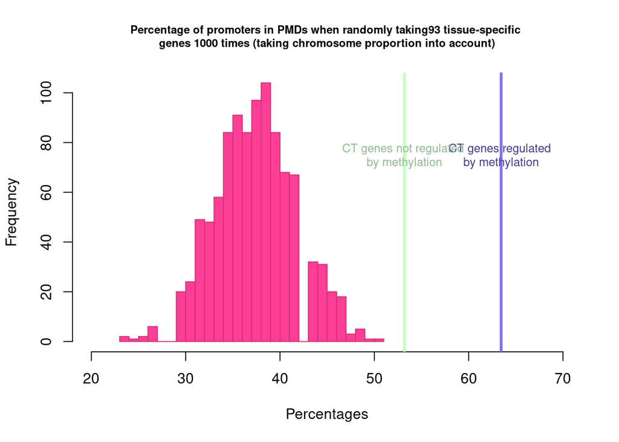

```r
random_percentage_chrprop <- function(i, data, nchrX, nautosomes){
  random_sample1 <- sample_n(filter(data, seqnames == "chrX"), nchrX)
  random_sample2 <- sample_n(filter(data, seqnames != "chrX"), nautosomes)
  random_sample <- rbind(random_sample1,random_sample2)
  random_sample_GR <- makeGRangesFromDataFrame(random_sample,
                                               keep.extra.columns = TRUE)
  length(subsetByOverlaps(random_sample_GR, my_PMD_GM23248_GR)) /
    length(random_sample_GR)*100
}

distrib_enriched <- unlist(bplapply(1:1000, random_percentage_chrprop,
                                    data = enriched_genes_analysable,
                                    nchrX = PMD_chr_repartition[[2]],
                                    nautosomes = PMD_chr_repartition[[1]]))
hist(distrib_enriched,
     col="violetred1",
     border = "violetred3",
     breaks = 20,
     main = paste0("Percentage of promoters in PMDs when randomly taking",
                   sum(table(CT_meth_regulated$PMD)),
                   " tissue-specific
genes 1000 times (taking chromosome proportion into account)"),
     cex.main = 0.75,
     xlab = "Percentages",
     ylab = "Frequency",
     xlim = c(20,70))
abline(v = PMD_perc, col = "slateblue1", lwd = 3)
text(PMD_perc, 75, "CT genes regulated
by methylation", col = "slateblue4", cex = 0.8)
abline(v = CT_not_meth_reg_PMD_perc, col = "darkseagreen1", lwd = 3)
text(CT_not_meth_reg_PMD_perc, 75, "CT genes not regulated
by methylation", col = "darkseagreen", cex = 0.8)
```

```r
PMD_CT_results <- rbind(dplyr::select(CT_not_meth_regulated,
                                      c(PMD, external_gene_name)),
                    dplyr::select(CT_meth_regulated,
                                  c(PMD, external_gene_name)))
CT_genes <- left_join(CT_genes, PMD_CT_results)
```

## 1.3 Methylation in an aging model : CD4+ cells

Now that we know that CT genes are indeed enriched in PMDs, we have to go further. Indeed, we know that proliferation has an impact on PMD and their methylation : there are losses of methylation with time. As CT genes are located in PMDs, we can hypothesise that their methylation might be impacted by the losses happening during proliferation. We thus want to focus on the impact on CT genes of the methylation changes happening on PMDss in proliferative or aging cells.

### 1.3.1 Data processing

Data coming from Heyn 2012 paper.

```bash
#!/bin/bash

#Newborn
/opt/sratoolkit/bin/fastq-dump --split-files --outdir ../rawdata --gzip SRR330578
/opt/sratoolkit/bin/fastq-dump --split-files --outdir ../rawdata --gzip SRR330579
/opt/sratoolkit/bin/fastq-dump --split-files --outdir ../rawdata --gzip SRR394135
/opt/sratoolkit/bin/fastq-dump --split-files --outdir ../rawdata --gzip SRR394136
/opt/sratoolkit/bin/fastq-dump --split-files --outdir ../rawdata --gzip SRR394137
/opt/sratoolkit/bin/fastq-dump --split-files --outdir ../rawdata --gzip SRR394138
/opt/sratoolkit/bin/fastq-dump --split-files --outdir ../rawdata --gzip SRR394139
/opt/sratoolkit/bin/fastq-dump --split-files --outdir ../rawdata --gzip SRR394140
/opt/sratoolkit/bin/fastq-dump --split-files --outdir ../rawdata --gzip SRR394141
/opt/sratoolkit/bin/fastq-dump --split-files --outdir ../rawdata --gzip SRR394142

#Centenarian
/opt/sratoolkit/bin/fastq-dump --split-files --outdir ../rawdata --gzip SRR330574
/opt/sratoolkit/bin/fastq-dump --split-files --outdir ../rawdata --gzip SRR330576
/opt/sratoolkit/bin/fastq-dump --split-files --outdir ../rawdata --gzip SRR330577
/opt/sratoolkit/bin/fastq-dump --split-files --outdir ../rawdata --gzip SRR330575

#Middle-age
/opt/sratoolkit/bin/fastq-dump --split-files --outdir ../rawdata --gzip SRR389249
/opt/sratoolkit/bin/fastq-dump --split-files --outdir ../rawdata --gzip SRR389248

for f in `cat CD4_SRA.txt`;

do mkdir /data/cbio/2021-mth-julie-devis/WGBS-processing/processed_data/$f;
cd /data/cbio/2021-mth-julie-devis/WGBS-processing/processed_data/$f;

#Trimming
/opt/TrimGalore/trim_galore --fastqc --path_to_cutadapt /home/users/jdevis/cutadapt --paired /data/cbio/2021-mth-julie-devis/WGBS-processing/rawdata/$f\_1.fastq /data/cbio/2021-mth-julie-devis/WGBS-processing/rawdata/$f\_2.fastq;

#Alignement
/home/users/jdevis/walt/bin/walt \
-i /data/cbio/2021-mth-julie-devis/WGBS-processing/genomes/hg38_by_Chr.dbindex \
-1 $f\_1_val_1.fq \
-2 $f\_2_val_2.fq \
-o $f\_mapping.mr;

#Duplicate-remover
LC_ALL=C sort -k 1,1 -k 2,2n -k 3,3n -k 6,6 -o $f.mr.sorted_start $f\_mapping.mr;
/opt/methpipe/build/duplicate-remover -S $f\_dremove_stat.txt -o $f.mr.dremove $f.mr.sorted_start;

#bsrate
/opt/methpipe/build/bsrate -c /data/cbio/GENOMES/GRCh38_by_Chr/hgdownload.cse.ucsc.edu/chromosomes \
-o $f.bsrate $f.mr.dremove;

#Methylation levels
/opt/methpipe/build/methcounts -n \
-c /data/cbio/GENOMES/GRCh38_by_Chr/hgdownload.cse.ucsc.edu/chromosomes \
-o $f.meth $f.mr.dremove;

#Merge CpG
/opt/methpipe/build/symmetric-cpgs -o $f\_CpG_merge.meth $f.meth;

#Stats
/opt/methpipe/build/levels -o $f.levels $f.meth

done
```

Bisulfite-Seq data coming from a male newborn, a middle age donor and a male centenarian.

Quality of the data is good, with a mean of 13 reads per cytosine. However, middle age data has no info about the sex of the donor. By comparing the number of reads by chromosome in this sample, a female one and the male ones, we saw that the proportion of reads on chromosomes X and Y showed that the middle age data come from a woman. We then have to be very careful when analysing the X chromosome with the middle age data. To facilitate the analysis and compare all samples, I’ll remove the adult data on chrX.

```r
columns <- c("chromosome", "position", "strand", "sequence context","methylation_level","number_of_reads")
CD4_newborn <- read_delim("data/CD4_newborn.meth",
    delim = "\t", escape_double = FALSE, col_names = FALSE, trim_ws = TRUE)
names(CD4_newborn) <- columns
CD4_middle <- read_delim("data/CD4_middle.meth",
    delim = "\t", escape_double = FALSE, col_names = FALSE, trim_ws = TRUE)
names(CD4_middle) <- columns
CD4_middle <- filter(CD4_middle, chromosome != "chrX")
CD4_cent <- read_delim("data/CD4_cent.meth",
    delim = "\t", escape_double = FALSE, col_names = FALSE, trim_ws = TRUE)
names(CD4_cent) <- columns
```

```r
CD4_newborn$age <- "newborn"
CD4_middle$age <- "middle_age"
CD4_cent$age <- "centenarian"
```

```r
CD4_newborn_GR <- makeGRangesFromDataFrame(CD4_newborn, start.field = "position",
                                           end.field = "position", keep.extra.columns = TRUE)
CD4_middle_GR <- makeGRangesFromDataFrame(CD4_middle, start.field = "position",
                                          end.field = "position", keep.extra.columns = TRUE)
CD4_cent_GR <- makeGRangesFromDataFrame(CD4_cent, start.field = "position",
                                        end.field = "position", keep.extra.columns = TRUE)
```

### 1.3.2 CT genes methylation level

Here I extract methylation for all CpGs located in CT genes promoter (regulated by methylation because it’s these that we can find in PMDs).

```r
CT_prom_GR <- makeGRangesFromDataFrame(CT_genes, start.field = "start_prom",
                                    end.field = "end_prom",
                                    keep.extra.columns = TRUE)

newborn <- mergeByOverlaps(CD4_newborn_GR, CT_prom_GR, ignore.strand = TRUE)[,1]
newborn$external_gene_name <- mergeByOverlaps(CD4_newborn_GR, CT_prom_GR,
                                              ignore.strand = TRUE)$external_gene_name
newborn <- as.data.frame(newborn)
middle <- mergeByOverlaps(CD4_middle_GR, CT_prom_GR, ignore.strand = TRUE)[,1]
middle$external_gene_name <- mergeByOverlaps(CD4_middle_GR, CT_prom_GR,
                                             ignore.strand = TRUE)$external_gene_name
middle <- as.data.frame(middle)
cent <- mergeByOverlaps(CD4_cent_GR, CT_prom_GR, ignore.strand = TRUE)[,1]
cent$external_gene_name <- mergeByOverlaps(CD4_cent_GR, CT_prom_GR,
                                           ignore.strand = TRUE)$external_gene_name
cent <- as.data.frame(cent)

CTmeth_inCD4 <- rbind(newborn, middle, cent)
rm(newborn, middle, cent)
CTmeth_inCD4$age <- factor(CTmeth_inCD4$age,
                           levels = c("newborn","middle_age","centenarian"))
CTmeth_inCD4[CTmeth_inCD4$number_of_reads == 0,]$methylation_level <- NA

length(unique(CTmeth_inCD4$external_gene_name))
```

```
## [1] 175
```

We can see here that we have information for all 175 CT genes. We now have to calculate the mean methylation level of each promoter to visualise it and compare to PMDs.

Some df that we obtain are empty, their CpG are not covered by the CD4 data, and so need to be removed. I also want to remove those who have data in only one age category, as we want to compare different age, they are of no need. When one of the age is missing, I’m adding it as NA to facilitate the rest (mostly gene on chrX and we removed data from adult)

```r
reorganize_data_genes <- function(gene_name, data){
  reorganized_data <- data %>%
    filter(external_gene_name == gene_name) %>%
    dplyr::select("start","methylation_level","age") %>%
    na.omit() %>%  # to remove CpG rows with NA meth_level
    pivot_wider(names_from = start, values_from = methylation_level) %>%
    column_to_rownames("age")
}

CT_per_gene_CD4_datasets <- sapply(unique(CTmeth_inCD4$external_gene_name),
                                   reorganize_data_genes, data = CTmeth_inCD4)

p <- rep(NA, length(CT_per_gene_CD4_datasets))
for(i in 1:length(CT_per_gene_CD4_datasets)){
 p[i] <- nrow(CT_per_gene_CD4_datasets[[i]]) > 1 &
   is.data.frame(CT_per_gene_CD4_datasets[[i]])
}
CT_per_gene_CD4_datasets <- CT_per_gene_CD4_datasets[p]

k <- rep(NA, length(CT_per_gene_CD4_datasets))
for(i in 1:length(CT_per_gene_CD4_datasets)){
  k[i] <- nrow(CT_per_gene_CD4_datasets[[i]]) == 2
}
for (gene in names(CT_per_gene_CD4_datasets[k])){
  tmp <- rep(NA, ncol(CT_per_gene_CD4_datasets[[gene]]))
  CT_per_gene_CD4_datasets[[gene]] <- rbind(CT_per_gene_CD4_datasets[[gene]], tmp)
  rownames(CT_per_gene_CD4_datasets[[gene]])[3] <-
    c("newborn","middle_age", "centenarian")[(!c("newborn","middle_age","centenarian") %in%
                                                rownames(CT_per_gene_CD4_datasets[[gene]]))]
  # naming the new row
}

for (gene in names(CT_per_gene_CD4_datasets)){
  CT_per_gene_CD4_datasets[[gene]] <- arrange(CT_per_gene_CD4_datasets[[gene]],
                                              rownames(CT_per_gene_CD4_datasets[[gene]]))
  # Put rows in the right order
}

rm(p, i, k, tmp)

CT_meth_means_pre <- sapply(CT_per_gene_CD4_datasets, rowMeans, na.rm = TRUE)

CT_meth_means <- CT_meth_means_pre %>%
  t() %>%
  as.data.frame() %>%
  rownames_to_column("external_gene_name")

CT_meth_means$middle_age[is.na(CT_meth_means$middle_age)] <- NA

n_means_meth <- CT_meth_means %>%
  filter(external_gene_name %in% CT_meth_regulated$external_gene_name) %>%
  nrow()

CT_genes <- left_join(CT_genes, CT_meth_means)
```

On the 175 CT genes, I have enough data to analyse 144 of them (97/125 meth regulated).

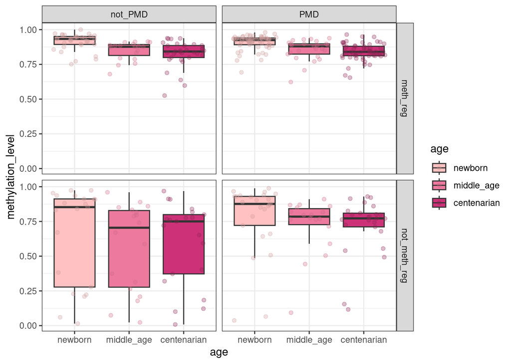

```r
CT_genes_to_plot <- CT_genes %>%
  dplyr::select(external_gene_name, chr, X_linked, regulated_by_methylation,
                PMD, newborn, middle_age, centenarian) %>%
  filter(!is.na(PMD)) %>%
  pivot_longer(names_to = "age", values_to = "methylation_level",
               - c("external_gene_name","chr","X_linked",
                   "regulated_by_methylation", "PMD"))
CT_genes_to_plot$age <- factor(CT_genes_to_plot$age,
                               levels = c("newborn","middle_age","centenarian"))
CT_genes_to_plot %>%
  mutate(PMD = case_when(PMD == TRUE ~ "PMD",
                         PMD == FALSE ~ "not_PMD")) %>%
  mutate(regulated_by_methylation = case_when(regulated_by_methylation == TRUE ~ "meth_reg",
                                              regulated_by_methylation == FALSE ~ "not_meth_reg")) %>%
  ggplot(aes(x = age, y = methylation_level, fill = age)) +
  geom_boxplot(outlier.shape = NA)+
  geom_jitter(aes(color = age), alpha = 0.3) +
  facet_grid(regulated_by_methylation ~ PMD) +
  scale_fill_manual(values = c("rosybrown1", "palevioletred2", "violetred3")) +
  scale_color_manual(values = c("rosybrown3","palevioletred3","violetred4")) +
  theme_bw()
```

### 1.3.3 Comparison CT and PMDs

```r
PMD_newborn <- mergeByOverlaps(CD4_newborn_GR, my_PMD_GM23248_GR, ignore.strand = TRUE)[,1]
PMD_newborn$name <- mergeByOverlaps(CD4_newborn_GR, my_PMD_GM23248_GR, ignore.strand = TRUE)$name
PMD_newborn <- as.data.frame(PMD_newborn)
PMD_middle <- mergeByOverlaps(CD4_middle_GR, my_PMD_GM23248_GR, ignore.strand = TRUE)[,1]
PMD_middle$name <- mergeByOverlaps(CD4_middle_GR, my_PMD_GM23248_GR, ignore.strand = TRUE)$name
PMD_middle <- as.data.frame(PMD_middle)
PMD_cent<- mergeByOverlaps(CD4_cent_GR, my_PMD_GM23248_GR, ignore.strand = TRUE)[,1]
PMD_cent$name <- mergeByOverlaps(CD4_cent_GR, my_PMD_GM23248_GR, ignore.strand = TRUE)$name
PMD_cent <- as.data.frame(PMD_cent)

PMD_CD4 <- rbind(PMD_newborn, PMD_middle, PMD_cent)
rm(PMD_newborn, PMD_middle, PMD_cent)
PMD_CD4$age <- factor(PMD_CD4$age, levels = c("newborn","middle_age","centenarian"))
PMD_CD4[PMD_CD4$number_of_reads == 0,]$methylation_level <- NA
```

Let’s compare the evolution of CT methylation with that of the PMDs they’re in.

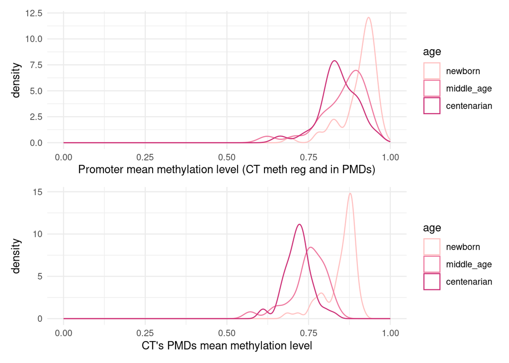

```r
CT_reg_PMD_plot <- CT_genes_to_plot %>%
  filter(regulated_by_methylation & PMD) %>%
  ggplot(aes(x = methylation_level, color = age)) +
  geom_density() +
  scale_color_manual(values = c("rosybrown1", "palevioletred2", "violetred3"))+
  xlab ("Promoter mean methylation level (CT meth reg and in PMDs)") +
  theme_minimal()


CT_reg_PMD_GR <- CT_prom_GR[!is.na(CT_prom_GR@elementMetadata$PMD) &
                              CT_prom_GR@elementMetadata$PMD &
                              CT_prom_GR@elementMetadata$regulated_by_methylation, ]

CT_PMD_meth_plot <- PMD_CD4 %>%
  filter(name %in% subsetByOverlaps(my_PMD_GM23248_GR,CT_reg_PMD_GR)$name) %>%
  group_by(name, age) %>%
  summarise("mean_methylation" = mean(methylation_level, na.rm = TRUE)) %>%
  ggplot(aes(x = mean_methylation, color = age)) +
  geom_density() +
  scale_color_manual(values = c("rosybrown1", "palevioletred2", "violetred3")) +
  theme_minimal() +
  xlab("CT's PMDs mean methylation level")
(CT_reg_PMD_plot + scale_x_continuous(limits = c(0,1))) / (CT_PMD_meth_plot + scale_x_continuous(limits = c(0,1)))
```

### 1.3.4 Comparison CT and non CT in PMDs

We don’t know if what we see happening in CT genes is common with other genes located in PMDs. If we can also see a demethylation of these genes promoters and that it is bigger than CT demethylation, it means that there would be a protection of CT genes against demethylation. We thus want to compare CT methylation to the one of other genes in PMDs.

#### 1.3.4.1 Non-CT methylation

Get methylation data for all other genes than CT in PMDs.

```r
non_CT_genes <- biomaRt_query %>%
  mutate(start_prom = case_when(strand == 1 ~ transcription_start_site - 1000,
                                strand == -1 ~ transcription_start_site - 500)) %>%
  mutate(end_prom = case_when(strand == 1 ~ transcription_start_site + 500,
                              strand == -1 ~ transcription_start_site + 1000)) %>%
  filter(!external_gene_name %in% CT_genes$external_gene_name) %>%
  filter(transcript_is_canonical == 1) %>%
  filter(chromosome_name%in%c(1:22, "X", "Y"))

non_CT_genes$strand <- ifelse(non_CT_genes$strand == "1", "+", "-")
seqlevelsStyle(non_CT_genes$chromosome_name) <- "UCSC"
non_CT_GR <- makeGRangesFromDataFrame(non_CT_genes,
                                      start.field = "start_prom",
                                      end.field = "end_prom",
                                      keep.extra.columns = TRUE)
non_CT_in_PMD <- subsetByOverlaps(non_CT_GR, my_PMD_GM23248_GR)

newborn <- mergeByOverlaps(CD4_newborn_GR, non_CT_in_PMD, ignore.strand = TRUE)[,1]
newborn$ensembl_gene_id <- mergeByOverlaps(CD4_newborn_GR, non_CT_in_PMD,
                                           ignore.strand = TRUE)$ensembl_gene_id
newborn <- as.data.frame(newborn)
middle <- mergeByOverlaps(CD4_middle_GR, non_CT_in_PMD, ignore.strand = TRUE)[,1]
middle$ensembl_gene_id <- mergeByOverlaps(CD4_middle_GR, non_CT_in_PMD,
                                          ignore.strand = TRUE)$ensembl_gene_id
middle <- as.data.frame(middle)
cent <- mergeByOverlaps(CD4_cent_GR, non_CT_in_PMD, ignore.strand = TRUE)[,1]
cent$ensembl_gene_id <- mergeByOverlaps(CD4_cent_GR, non_CT_in_PMD,
                                        ignore.strand = TRUE)$ensembl_gene_id
cent <- as.data.frame(cent)

nonCTmeth_inCD4 <- rbind(newborn, middle, cent)
rm(newborn, middle, cent)
nonCTmeth_inCD4$age <- factor(nonCTmeth_inCD4$age,
                           levels = c("newborn","middle_age","centenarian"))
nonCTmeth_inCD4[nonCTmeth_inCD4$number_of_reads == 0,]$methylation_level <- NA

reorganize_data_ensembl <- function(gene_name, data){
  reorganized_data <- data %>%
    filter(ensembl_gene_id == gene_name) %>%
    dplyr::select("start","methylation_level","age") %>%
    na.omit() %>%  # to remove CpG rows with NA meth_level
    pivot_wider(names_from = start, values_from = methylation_level) %>%
    column_to_rownames("age")
}

# nonCT_per_gene_CD4_datasets <- bplapply(unique(nonCTmeth_inCD4$ensembl_gene_id),
#                                       reorganize_data_ensembl, data = nonCTmeth_inCD4,
#                                       BPPARAM = MulticoreParam(8L))
# names(nonCT_per_gene_CD4_datasets) <- unique(nonCTmeth_inCD4$ensembl_gene_id)
#
# p <- rep(NA, length(nonCT_per_gene_CD4_datasets))
# for(i in 1:length(nonCT_per_gene_CD4_datasets)) {
#  p[i] <- nrow(nonCT_per_gene_CD4_datasets[[i]]) > 1 &
#    is.data.frame(nonCT_per_gene_CD4_datasets[[i]])
# }
# nonCT_per_gene_CD4_datasets <- nonCT_per_gene_CD4_datasets[p]
#
# k <- rep(NA, length(nonCT_per_gene_CD4_datasets))
# for(i in 1:length(nonCT_per_gene_CD4_datasets)) {
#   k[i] <- nrow(nonCT_per_gene_CD4_datasets[[i]]) == 2
# }
#
# for (gene in names(nonCT_per_gene_CD4_datasets[k])) {
#   print(gene)
#   tmp <- rep(NA, ncol(nonCT_per_gene_CD4_datasets[[gene]]))
#   nonCT_per_gene_CD4_datasets[[gene]] <- rbind(nonCT_per_gene_CD4_datasets[[gene]], tmp)
#   rownames(nonCT_per_gene_CD4_datasets[[gene]])[3] <-
#     c("newborn","middle_age", "centenarian")[(!c("newborn","middle_age","centenarian") %in%
#                                                 rownames(nonCT_per_gene_CD4_datasets[[gene]]))]
#   # naming the new row
# }
#
# for (gene in names(nonCT_per_gene_CD4_datasets)) {
#   nonCT_per_gene_CD4_datasets[[gene]] <- arrange(nonCT_per_gene_CD4_datasets[[gene]],
#                                               rownames(nonCT_per_gene_CD4_datasets[[gene]]))
#   # Put rows in the right order
# }
#
# rm(p, i, k, tmp)
# save(nonCT_per_gene_CD4_datasets,
#      file = "data_rmd/nonCT_per_gene_CD4_datasets.rda")

load("data_rmd/nonCT_per_gene_CD4_datasets.rda")

nonCT_meth_means_tmp <- sapply(nonCT_per_gene_CD4_datasets, rowMeans, na.rm = TRUE)
nonCT_meth_means <- Reduce(rbind, nonCT_meth_means_tmp) %>%
  data.frame()
nonCT_meth_means$ensembl_gene_id <- names(nonCT_meth_means_tmp)

nonCT_meth_means$middle_age[is.na(nonCT_meth_means$middle_age)] <- NA
```

#### 1.3.4.2 CT and non CT comparison

```r
threshold <- CT_genes %>%
  filter(regulated_by_methylation & PMD) %>%
  dplyr::select(newborn) %>%
  min(na.rm = TRUE)

nonCT_meth_means_thr <- nonCT_meth_means %>%
  filter(newborn >= threshold)

nonCT_meth_means_to_plot <-  nonCT_meth_means_thr %>%
  pivot_longer(names_to = "age", values_to = "methylation_level",
               - "ensembl_gene_id")
nonCT_meth_means_to_plot$age <- factor(nonCT_meth_means_to_plot$age,
                               levels = c("newborn","middle_age","centenarian"))


med_meth_nb_CT <- CT_genes_to_plot %>%
  filter(regulated_by_methylation & PMD & age == "newborn") %>%
  pull(methylation_level) %>%
  median(na.rm = TRUE)
med_meth_nb_CT
```

```
## [1] 0.9247734
```

```r
med_meth_nb_nonCT <-nonCT_meth_means_to_plot %>%
  filter(age == "newborn") %>%
  pull(methylation_level) %>%
  median(na.rm = TRUE)
med_meth_nb_nonCT
```

```
## [1] 0.890181
```

```r
med_meth_cent_CT <- CT_genes_to_plot %>%
  filter(regulated_by_methylation & PMD & age == "centenarian") %>%
  pull(methylation_level) %>%
  median(na.rm = TRUE)
med_meth_cent_CT
```

```
## [1] 0.8399923
```

```r
med_meth_cent_nonCT <-nonCT_meth_means_to_plot %>%
  filter(age == "centenarian") %>%
  pull(methylation_level) %>%
  median(na.rm = TRUE)
med_meth_cent_nonCT
```

```
## [1] 0.7365126
```

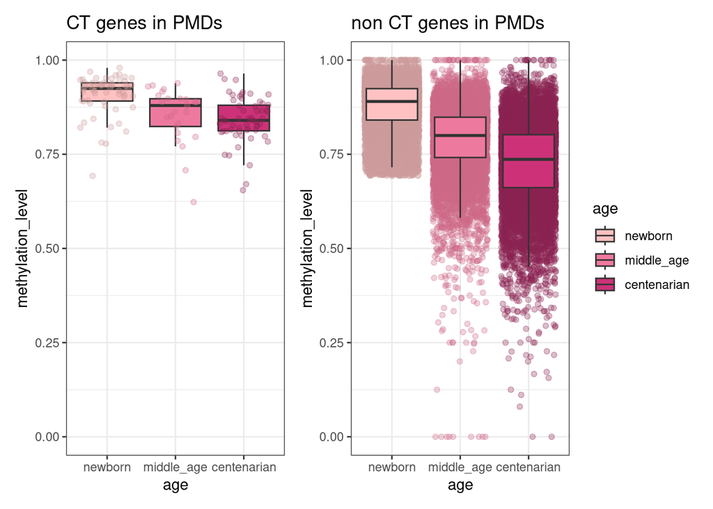

```r
CT_reg_PMD_boxplot <- CT_genes_to_plot %>%
  filter(regulated_by_methylation & PMD) %>%
  ggplot(aes(x = age, y = methylation_level, fill = age)) +
  geom_boxplot(outlier.shape = NA)+
  geom_jitter(aes(color = age), alpha = 0.3) +
  scale_fill_manual(values = c("rosybrown1", "palevioletred2", "violetred3")) +
  scale_color_manual(values = c("rosybrown3","palevioletred3","violetred4")) +
  theme_bw()


nonCT_boxplot <- nonCT_meth_means_to_plot %>%
  ggplot(aes(x = age, y = methylation_level, fill = age)) +
  geom_jitter(aes(color = age), alpha = 0.3) +
  geom_boxplot(outlier.shape = NA) +
  scale_fill_manual(values = c("rosybrown1", "palevioletred2", "violetred3")) +
  scale_color_manual(values = c("rosybrown3","palevioletred3","violetred4")) +
  theme_bw()


(CT_reg_PMD_boxplot + ggtitle("CT genes in PMDs") +
    scale_y_continuous(limits = c(0,1)) + theme(legend.position = "none")) +
  (nonCT_boxplot + ggtitle("non CT genes in PMDs") +
     scale_y_continuous(limits = c(0,1)))
```

#### 1.3.4.3 Differential analysis

However, this is only an observation based on the data, we need to do a quantification of this decrease and see its signification. For this, we have to do a differential methylation analysis.

First step is to check that there is indeed a loss between newborn and centenarian for each gene. To do so, we use a unidirectional (newborn > centenarian) paired statistical test on the methylation level of cytosines in both ages. Data can’t really be normalise so we use a Wilcoxon test (non-parametric t test). Our significativity threshold is 5%, which means that a test is significative if the adjusted (B-H method) pvalue is inferior to 0.05.

Second step is to quantify the loss of methylation between newborn and centenarian. To do so, we calculate a delta_meth for each gene, which is simply the difference between newborn and cent level.

```r
CT_to_pval <- CTmeth_inCD4 %>%
  filter(external_gene_name %in% filter(CT_genes,
                                        PMD & regulated_by_methylation)$external_gene_name) %>%
  dplyr::select(external_gene_name, seqnames, start, age, methylation_level) %>%
  pivot_wider(names_from = "age", values_from = "methylation_level", values_fill = NA) %>%
  filter(!is.na(newborn) & !is.na(centenarian)) %>%
  left_join(dplyr::select(CT_genes, external_gene_name, ensembl_gene_id))
non_CT_to_pval <- nonCTmeth_inCD4 %>%
  filter(ensembl_gene_id %in% nonCT_meth_means_thr$ensembl_gene_id) %>%
  dplyr::select(ensembl_gene_id, seqnames, start, age, methylation_level) %>%
  pivot_wider(names_from = "age", values_from = "methylation_level", values_fill = NA) %>%
  filter(!is.na(newborn) & !is.na(centenarian))

test_nb_cent <- function(gene_i, data){
    wilcox.test(
      as.matrix(filter(data, ensembl_gene_id == gene_i)$newborn),
      as.matrix(filter(data, ensembl_gene_id == gene_i)$centenarian),
      paired = TRUE,
      alternative = "greater",
      exact = FALSE)$p.value
}

pval_CT <- sapply(unique(CT_to_pval$ensembl_gene_id), test_nb_cent, CT_to_pval)
pval_nonCT <- sapply(unique(non_CT_to_pval$ensembl_gene_id), test_nb_cent, non_CT_to_pval)


CT_stat_analysis <- CT_genes %>%
  filter(ensembl_gene_id %in% CT_to_pval$ensembl_gene_id) %>%
  dplyr::select(ensembl_gene_id, external_gene_name, chr, X_linked,
                 newborn, middle_age, centenarian) %>%
  filter(!is.na(newborn) & !is.na(centenarian)) %>%
  mutate("padj" = p.adjust(pval_CT, method = "BH"))
sign_table_CT <- table(CT_stat_analysis$padj < 0.05)

nonCT_stat_analysis <- nonCT_meth_means_thr %>%
  filter(ensembl_gene_id %in% non_CT_to_pval$ensembl_gene_id) %>%
  mutate("padj" = p.adjust(pval_nonCT, method = "BH"))
sign_table_nonCT <- table(nonCT_stat_analysis$padj < 0.05)

table(CT_stat_analysis$padj <= 0.05)[[2]]/length(CT_stat_analysis$padj)
```

```
## [1] 0.5517241
```

```r
table(nonCT_stat_analysis$padj <= 0.05)[[2]]/length(nonCT_stat_analysis$padj)
```

```
## [1] 0.639206
```

```r
CT_stat_analysis <- CT_stat_analysis %>%
  mutate("delta_meth" = centenarian - newborn)

nonCT_stat_analysis <- nonCT_stat_analysis %>%
  mutate("delta_meth" = centenarian - newborn)

med_delta_CT <- CT_stat_analysis %>%
  filter(padj <= 0.05) %>%
  pull(delta_meth) %>%
  median()
med_delta_CT
```

```
## [1] -0.09740241
```

```r
med_delta_nonCT <- nonCT_stat_analysis %>%
  filter(padj <= 0.05) %>%
  pull(delta_meth) %>%
  median()
med_delta_nonCT
```

```
## [1] -0.1630711
```

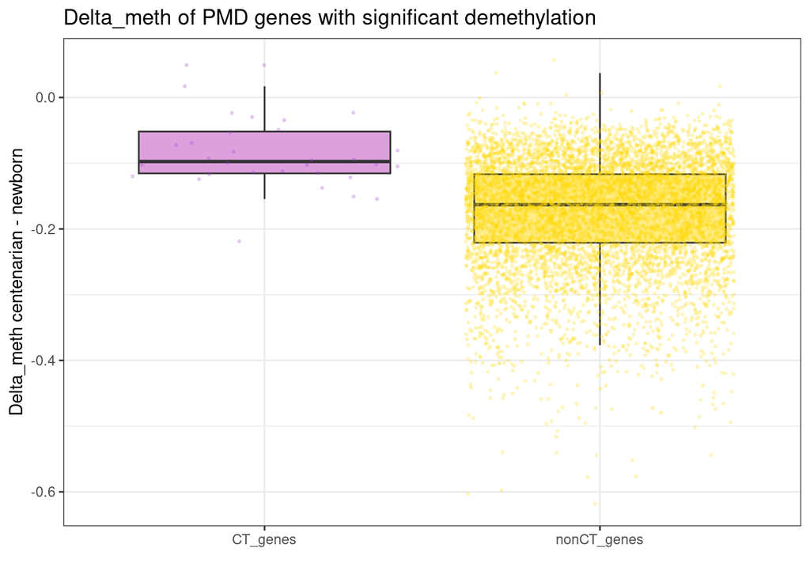

```r
CT_stat_analysis %>%
  filter(padj <= 0.05) %>%
  mutate(type = "CT_genes") %>%
  dplyr::select(ensembl_gene_id, centenarian, middle_age, newborn, padj, delta_meth, type) %>%
  rbind(nonCT_stat_analysis %>%
          filter(padj <= 0.05) %>%
          mutate(type = "nonCT_genes")) %>%

  ggplot(aes(y = delta_meth, x = type, fill = type)) +
  geom_boxplot(outlier.shape = NA) +
  geom_jitter(aes(color = type), alpha = 0.2, size = 0.5) +
  scale_fill_manual(values = c("plum","lightgoldenrod1")) +
  scale_color_manual(values = c("darkorchid3","gold1")) +
  ggtitle("Delta_meth of PMD genes with significant demethylation") +
  xlab("") +
  ylab("Delta_meth centenarian - newborn") +
  theme_bw() +
  theme(legend.position = "none")
```

There is indeed a difference in the amplitude of delta_meth between CT and nonCT genes in PMD.

We then want to test the difference between delta_meth for CT and nonCT genes in PMD, when pval is significative. For that we use a unidirectionnal (CT > non-CT) Mann-Whitney test, non-parametric (because no normality in delta_meth non-CT) version of student t test.

```r
wilcox.test(filter(CT_stat_analysis, padj <= 0.05)$delta_meth,
            filter(nonCT_stat_analysis, padj <= 0.05)$delta_meth,
            alternative = "greater")
```

```
##
##  Wilcoxon rank sum test with continuity correction
##
## data:  filter(CT_stat_analysis, padj <= 0.05)$delta_meth and filter(nonCT_stat_analysis, padj <= 0.05)$delta_meth
## W = 192767, p-value = 7.423e-11
## alternative hypothesis: true location shift is greater than 0
```

pvalue here is significative. This shows then that delta_meth are smaller in nonCT genes and demethylation in nonCT genes is then higher than in CT genes.

However, the difference between delta_meth distributions could be the result of the biggest number of genes in nonCT (4108 VS 26 not sign, or 7278 VS 32 padj sign). In order to see that, let’s do a down sampling : taking 32 nonCT genes with a pval <= 0.05 and 26 with a pval > 0.05 a thousand times and calculate the mean of each distributions. I can visualise that after and see where CT genes goes compare to that.

```r
random_delta_distrib_means <- function(i, data, n_sign, n_notsign){
  random_sample1 <- sample_n(filter(data, padj <= 0.05), n_sign)
  random_sample2 <- sample_n(filter(data, padj > 0.05), n_notsign)
  random_sample <- rbind(random_sample1, random_sample2)

  mean(random_sample$delta_meth)
}

distrib_means <- unlist(bplapply(1:1000, random_delta_distrib_means,
                                data = nonCT_stat_analysis,
                                n_sign = sign_table_CT[[2]],
                                n_notsign = sign_table_CT[[1]]))

mean(CT_stat_analysis$delta_meth)
```

```
## [1] -0.06639918
```

```r
table(distrib_means >= mean(CT_stat_analysis$delta_meth))
```

```
##
## FALSE
##  1000
```

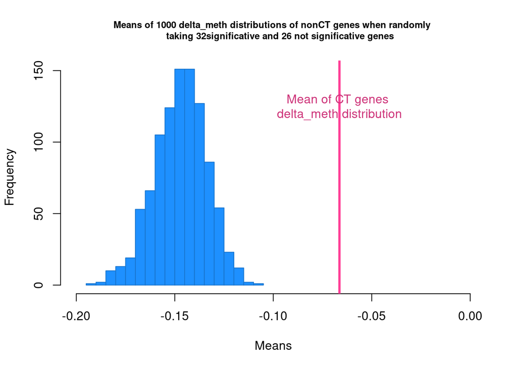

```r
hist(distrib_means,
     col="dodgerblue1",
     border = "dodgerblue3",
     breaks = 20,
     main = paste0("Means of 1000 delta_meth distributions of nonCT genes when randomly
     taking ", sign_table_CT[[2]], "significative and ", sign_table_CT[[1]], " not significative genes"),
     cex.main = 0.75,
     xlab = "Means",
     ylab = "Frequency",
     xlim = c(-0.2, 0))
abline(v = mean(CT_stat_analysis$delta_meth), col = "violetred1", lwd = 3)
text(mean(CT_stat_analysis$delta_meth), 125, "Mean of CT genes
delta_meth distribution", col = "violetred3")
```

This shows that even with the same amount of genes, delta_meth are significantly smaller for CT genes than for nonCT genes, the effect is then not due to the amount of genes.

This analysis shows that CT genes located in PMDs undergo a demethylation related to aging that is smaller than the other genes in PMDs. Thus, age and demethylation that is associated to it couldn’t explain demethylation and activation of CT genes. There is then probably something that protects CT genes from PMD demethylation.

## 1.4 Why is there a protection on CT genes : CpG density hypothesis

CT genes are thus protected against demethylation in PMDs. Next question is to determine what confers this protection to CT genes. what One of our hypothesis for that protection is that CT genes are protected thanks to their density in CpG. Indeed, CT genes promoters are rich in CpGs while PMDs are poor. It is possible that this density protects CT genes from demethylation.

Promoter’s density in CpG is already computed in CTexploreR but we have to do it also for non-CT genes.

```r
CT_density_analysis <- CT_genes %>%
  filter(ensembl_gene_id %in% CT_stat_analysis$ensembl_gene_id) %>%
  mutate("padj" = CT_stat_analysis$padj) %>%
  mutate("delta_meth" = CT_stat_analysis$delta_meth)

nonCT_density_analysis <- as.data.frame(non_CT_in_PMD) %>%
  filter(ensembl_gene_id %in% nonCT_stat_analysis$ensembl_gene_id)%>%
  left_join(nonCT_stat_analysis)
colnames(nonCT_density_analysis)[1:3] <- c("chr", "start_prom", "end_prom")
nonCT_density_analysis$chr <- as.character(nonCT_density_analysis$chr)

cpg_density <- function(gene, data){
  temp <- data %>%
    filter(ensembl_gene_id == gene) %>%
    dplyr::select(ensembl_gene_id, start_prom, end_prom, chr)

  seqlevelsStyle(temp$chr) <- "NCBI"

  chrom <- genome[startsWith(names(genome), paste0(temp$chr, " "))][[1]]

  interest <- subseq(chrom, temp$start_prom, temp$end_prom)

  p <- matchPattern("CG", interest)
  length(p) / length(interest)
}

genome <- readDNAStringSet("../../cluster/GENOMES/Homo_sapiens.GRCh38.dna.primary_assembly.fa")

CT_cpg_density <- sapply(CT_density_analysis$ensembl_gene_id, cpg_density,
                         CT_density_analysis)

nonCT_cpg_density <- unlist(bplapply(nonCT_density_analysis$ensembl_gene_id, cpg_density,
                            nonCT_density_analysis))
```

There is already the CpG_density column from CT_genes so careful, what I’ve done here is similar to what was already in it, it confirms.

### 1.4.1 Comparison CT and non CT with similar densities

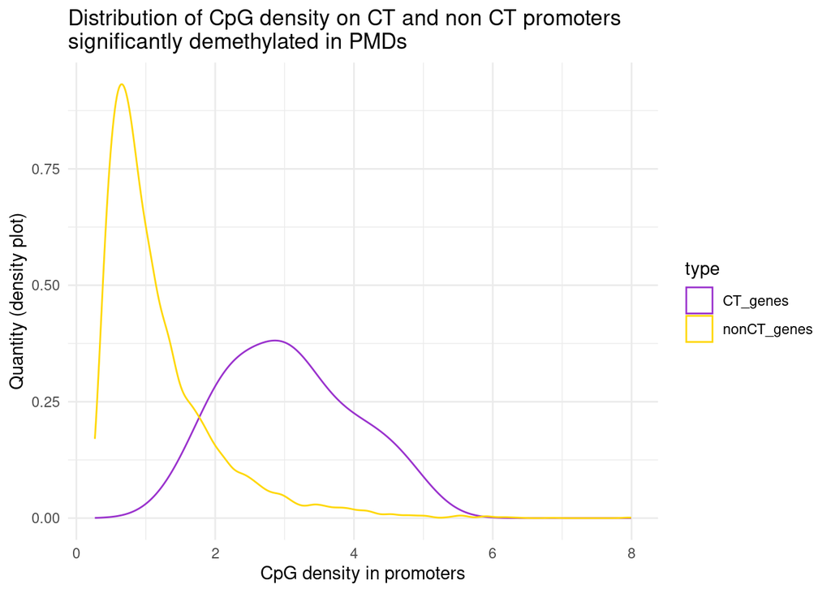

```r
CT_density_analysis <- CT_density_analysis %>%
  mutate("CpG_density_analysis" = CT_cpg_density*100)

nonCT_density_analysis <- nonCT_density_analysis %>%
  mutate("CpG_density_analysis" = nonCT_cpg_density*100)

CT_density_analysis %>%
  filter(padj <= 0.05) %>%
  mutate(type = "CT_genes") %>%
  dplyr::select(ensembl_gene_id, centenarian, middle_age, newborn, padj,
                delta_meth, CpG_density_analysis, type) %>%
  rbind(nonCT_density_analysis %>%
          filter(padj <= 0.05) %>%
          mutate(type = "nonCT_genes") %>%
          dplyr::select(ensembl_gene_id, centenarian, middle_age, newborn, padj,
                delta_meth, CpG_density_analysis, type)) %>%

  ggplot(aes(x = CpG_density_analysis, color = type)) +
  geom_density() +
  scale_color_manual(values = c("darkorchid3","gold1")) +
  xlab("CpG density in promoters") +
  ylab("Quantity (density plot)") +
  ggtitle("Distribution of CpG density on CT and non CT promoters
significantly demethylated in PMDs")+
  theme_minimal()
```

This shows/confirms that nonCT promoters in PMDs are poorer in CpG.

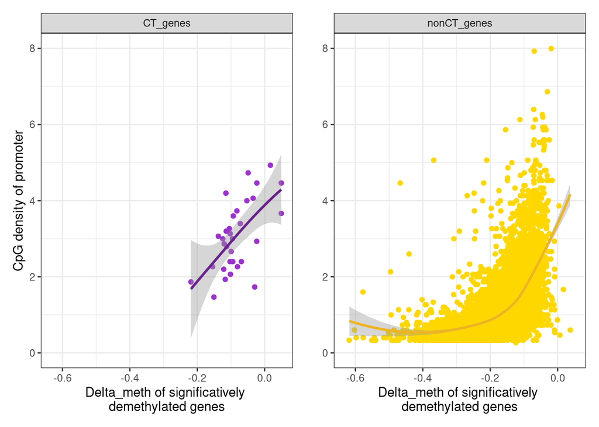

```r
CT_density_analysis %>%
  filter(padj <= 0.05) %>%
  mutate(type = "CT_genes") %>%

  ggplot(aes(x = delta_meth, y = CpG_density_analysis, color = type)) +
  geom_point() +
  geom_smooth(method = "loess", span = 2.5, color = "darkorchid4") +
  scale_color_manual(values = c("darkorchid3")) +
  xlab("Delta_meth of significatively
demethylated genes") +
  ylab("CpG density of promoter") +
  facet_grid(~ type) +
  theme_bw() +
  theme(legend.position = "none") +
  scale_y_continuous(limits = c(0, 8)) +
  scale_x_continuous(limits = c(-0.63, 0.05)) +

  nonCT_density_analysis %>%
          filter(padj <= 0.05) %>%
          mutate(type = "nonCT_genes") %>%

  ggplot(aes(x = delta_meth, y = CpG_density_analysis, color = type)) +
  geom_point() +
  geom_smooth(method = "loess", span = 0.75, color = "goldenrod2") +
  scale_color_manual(values = c("gold1")) +
  facet_grid(~ type) +
  theme_bw() +
  ylab("") +
  xlab("Delta_meth of significatively
demethylated genes") +
  scale_y_continuous(limits = c(0, 8)) +
  scale_x_continuous(limits = c(-0.63, 0.05)) +
  theme(legend.position = "none")
```

We see here a diagonal tendancy with a positive correlation, it shows that there is a link between CpG density and delta_meth. This tendancy is visible in CT and nonCT : the more CpG there are in promoters, less demethylation we observe. Isolated CpGs are then probably those that are easier demethylated in PMDs. We thus propose that the strong density in CpG that characterize CT promoters is the origin of their resistance to demethylation

Let’s compare only similar CpG densities, and do the same categories as in CTexploreR.

```r
CT_density_analysis <- CT_density_analysis %>%
  mutate(density_state =
             case_when (CT_density_analysis$CpG_density_analysis >= 4 ~ "rich",
                        CT_density_analysis$CpG_density_analysis <= 2 ~ "poor",
                        CT_density_analysis$CpG_density_analysis > 2 &
                          CT_density_analysis$CpG_density_analysis < 4 ~ "normal"))


nonCT_density_analysis <- nonCT_density_analysis %>%
  mutate(density_state =
             case_when (nonCT_density_analysis$CpG_density_analysis >= 4 ~ "rich",
                        nonCT_density_analysis$CpG_density_analysis <= 2 ~ "poor",
                        nonCT_density_analysis$CpG_density_analysis > 2 &
                          nonCT_density_analysis$CpG_density_analysis < 4 ~ "normal"))
```

By comparing only delta_meth from genes normal/rich in CpG, we can erase the effect of CpG density from the demethylation analysis.

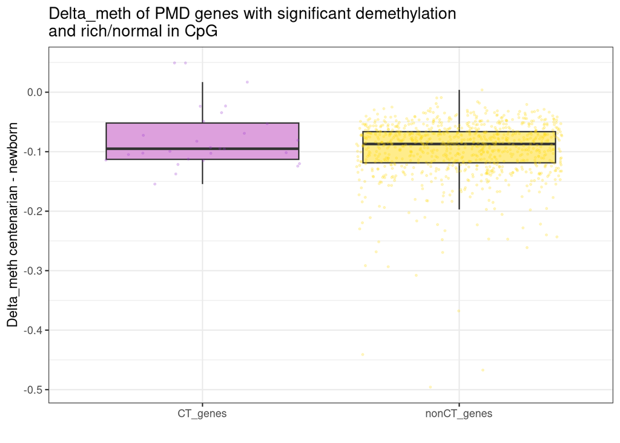

```r
CT_density_analysis %>%
  filter(padj <= 0.05) %>%
  filter(density_state != "poor") %>%
  mutate(type = "CT_genes") %>%
  dplyr::select(ensembl_gene_id, delta_meth, type) %>%
  rbind(nonCT_density_analysis %>%
          filter(padj <= 0.05) %>%
          filter(density_state != "poor") %>%
          mutate(type = "nonCT_genes")%>%
          dplyr::select(ensembl_gene_id, delta_meth, type))%>%

  ggplot(aes(y = delta_meth, x = type, fill = type)) +
  geom_boxplot(outlier.shape = NA) +
  geom_jitter(aes(color = type), alpha = 0.2, size = 0.5) +
  scale_fill_manual(values = c("plum","lightgoldenrod1")) +
  scale_color_manual(values = c("darkorchid3","gold1")) +
  ggtitle("Delta_meth of PMD genes with significant demethylation
and rich/normal in CpG") +
  xlab("") +
  ylab("Delta_meth centenarian - newborn") +
  theme_bw() +
  theme(legend.position = "none")
```

```r
rich_med_delta_CT <- CT_density_analysis %>%
  filter(padj <= 0.05 & density_state != "poor") %>%
  pull(delta_meth) %>%
  median()
rich_med_delta_CT
```

```
## [1] -0.0950296
```

```r
rich_med_delta_nonCT <-nonCT_density_analysis %>%
  filter(padj <= 0.05 & density_state != "poor") %>%
  pull(delta_meth) %>%
  median()
rich_med_delta_nonCT
```

```
## [1] -0.0870772
```

Medians are now way closer to each other and we can see that distributions are closer to each other. For CT genes, the median is still a loss of 9.5029605%, however for nonCT the median loss has reduce to 8.7077204% ! The two distributions are now clearly comparable. It looks like the demethylation difference that we observed earlier between CT and nonCT genes in PMD during aging is now gone when we only analyse gene whose promoters are not poor in CpG.

Let’s do the same test as previously to see if there is a difference between both distributions (Mann-Withney) and if it isn’t due to the size of the sample.

```r
wilcox.test(filter(CT_density_analysis, padj <= 0.05 & density_state != "poor")$delta_meth,
            filter(nonCT_density_analysis, padj <= 0.05 & density_state != "poor")$delta_meth,
            alternative = "greater")
```

```
##
##  Wilcoxon rank sum test with continuity correction
##
## data:  filter(CT_density_analysis, padj <= 0.05 & density_state != "poor")$delta_meth and filter(nonCT_density_analysis, padj <= 0.05 & density_state != "poor")$delta_meth
## W = 13765, p-value = 0.2211
## alternative hypothesis: true location shift is greater than 0
```

```r
rich_CT_sign <- table(filter(CT_density_analysis, density_state != "poor")$padj <= 0.05)

distrib_means_rich <- unlist(bplapply(1:1000, random_delta_distrib_means,
                                data = filter(nonCT_density_analysis, density_state != "poor"),
                                n_sign = rich_CT_sign[[2]], n_notsign = rich_CT_sign[[1]]))

mean_delta_rich <- mean(filter(CT_density_analysis, density_state != "poor")$delta_meth)
mean_delta_rich
```

```
## [1] -0.05858177
```

```r
table(distrib_means_rich >= mean(filter(CT_density_analysis,
                                        density_state != "poor")$delta_meth))
```

```
##
## FALSE  TRUE
##   830   170
```

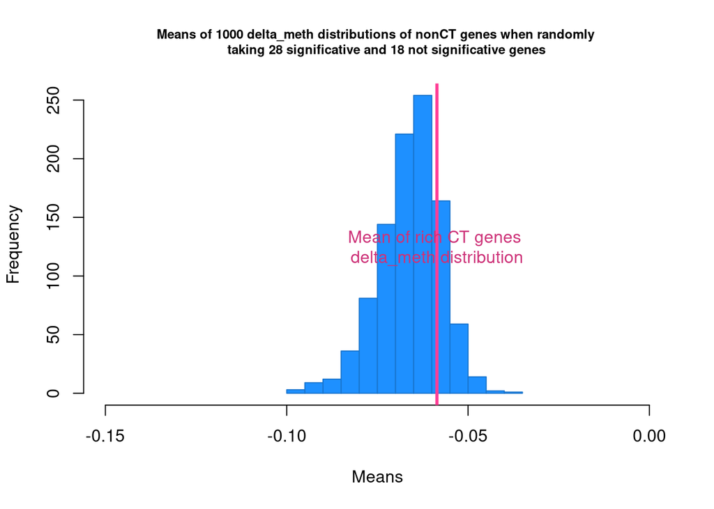

```r
hist(distrib_means_rich,
     col="dodgerblue1",
     border = "dodgerblue3",
     breaks = 20,
     main = paste0("Means of 1000 delta_meth distributions of nonCT genes when randomly
     taking ", rich_CT_sign[[2]], " significative and ", rich_CT_sign[[1]], " not significative genes"),
     cex.main = 0.75,
     xlab = "Means",
     ylab = "Frequency",
     xlim = c(-0.15, 0))
abline(v = mean_delta_rich, col = "violetred1", lwd = 3)
text(mean_delta_rich, 125, "Mean of rich CT genes
delta_meth distribution", col = "violetred3")
```

pvalue is not significative anymore which means that there is ano difference between both distribution.

Also, we can see when doing 1000 mean of delta_meth with the same amount of genes that the mean for CT genes is in the middle of the distribution, which means that there is no real difference between CT and nonCT demethylation when taking the CpG density into account

It thus looks like CpG density plays a big role in the protection as when we’re taking that into account in our analysis, the difference between CT and nonCT disappears.

When analysing genes with comlparable CpG density, there is no difference in the demethylation of CT and nonCT genes in PMD. This shows that the richness in CpG of the promoter gives a certain protection against PMD demethylation during aging.

### 1.4.2 solo-CpG methylation

In summary, although CT genes are found in PMDs, they lose little methylation and are protected from continued demethylation during aging. This protection seems to be explained by the CpG density of the promoters. The demethylation of CT genes visible in tumours is therefore not associated with cell proliferation. However, the question remains: why does a high CpG density protect against continued demethylation? Our hypothesis is that there may be a self-maintenance system, i.e. when a CpG loses its methylation in a CpG-rich region, the other still methylated CpG methylated CpGs attract the methylation maintenance machinery, thereby promoting the remethylation of the demethylated site. It should be noted that our observations are consistent with some analyses performed by Zhou et al. (2018) which showed that that the hypomethylation of PMDs was better observed by focusing only on the methylation of certain CpGs, called “solo-CpGs”, corresponding to isolated CpGs at least 35 bp away from a neighbouring CpG and flanked by a A or a T (WCGW).

We’re going to use Zhou’s coordinate of solo-WCGW to look a bit more into that.

```r
solo_WCGW <- read_delim("data/zhou_solo_WCGW_hg38.bed",
    delim = "\t", escape_double = FALSE,
    col_names = FALSE, trim_ws = TRUE)
solo_WCGW <- solo_WCGW[, -5]
colnames(solo_WCGW) <- c("seqnames", "start", "end", "context")
```

```r
CT_with_solo <- CTmeth_inCD4 %>%
  filter(external_gene_name %in% filter(CT_genes,
                                        PMD & regulated_by_methylation)$external_gene_name) %>%
  dplyr::select(external_gene_name, seqnames, start, age, methylation_level) %>%
  left_join(dplyr::select(CT_genes, external_gene_name, ensembl_gene_id)) %>%
  left_join(solo_WCGW)
CT_with_solo <- CT_with_solo %>%
  mutate(solo_state = case_when(is.na(CT_with_solo$context) ~ "not-solo",
                                !is.na(CT_with_solo$context) ~ "solo-CpG")) %>%
  mutate(type = "CT_genes")



nonCT_with_solo <- nonCTmeth_inCD4 %>%
  filter(ensembl_gene_id %in% nonCT_meth_means_thr$ensembl_gene_id) %>%
  dplyr::select(ensembl_gene_id, seqnames, start, age, methylation_level) %>%
  left_join(solo_WCGW)
```

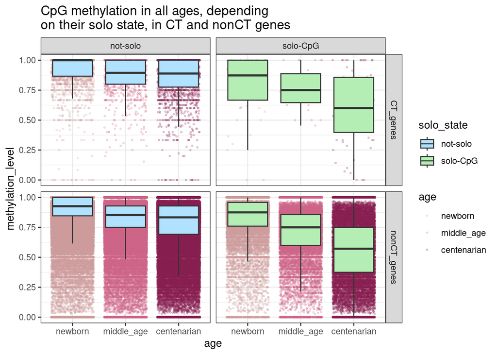

```r
nonCT_with_solo <- nonCT_with_solo %>%
  mutate(solo_state = case_when(is.na(nonCT_with_solo$context) ~ "not-solo",
                                !is.na(nonCT_with_solo$context) ~ "solo-CpG"))%>%
  mutate(type = "nonCT_genes")

CT_with_solo %>%
  dplyr::select(colnames(nonCT_with_solo)) %>%
  rbind(nonCT_with_solo) %>%

  ggplot(aes(y = methylation_level, x = age,
             fill = solo_state)) +
  geom_jitter(aes(color = age), alpha = 0.2, size = 0.5) +
  geom_boxplot(outlier.shape = NA) +
  scale_fill_manual(values = c("lightskyblue1", "darkseagreen2")) +
  scale_color_manual(values = c("rosybrown3","palevioletred3","violetred4")) +
  ggtitle("CpG methylation in all ages, depending
on their solo state, in CT and nonCT genes") +
  facet_grid(type ~ solo_state) +
  theme_bw()
```

What we see here confirms what zhou said and what we hypothesize, we can see that solo-cpg are losing more methylation following aging.